# Linear Regression

```python
import warnings
warnings.filterwarnings('ignore')
```

```python
import random
import pandas as pd
import numpy as np
import matplotlib.pyplot as plt
import seaborn as sns
from plotnine import *
from statsmodels.formula.api import ols
from sklearn.neighbors import KNeighborsClassifier
from sklearn.model_selection import train_test_split
```

```python
# Defining the python equivalent of R abline function.

def abline(intercept, slope):
    """Plot a line from slope and intercept"""
    axes = plt.gca()
    x_vals = np.array(axes.get_xlim())
    y_vals = intercept + slope * x_vals
    plt.plot(x_vals, y_vals, '--')
```

**Load the `prostate_cancer.csv` dataset. Draw a scatterplot of smoothness x against symmetry y.**

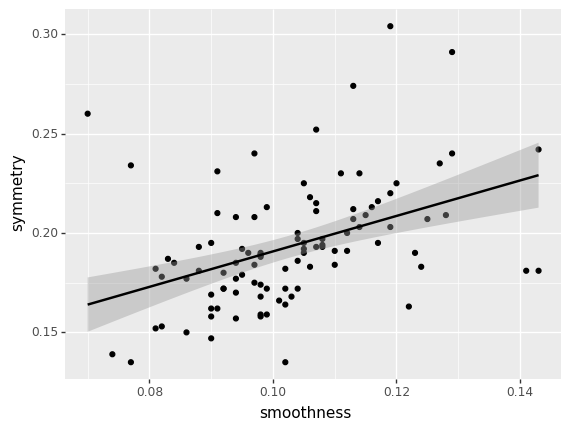

```python
df = pd.read_csv('prostate_cancer.csv')
p = ggplot(aes(x='smoothness', y='symmetry'), df)
p + geom_point()+ geom_smooth(method="lm",size=1)
```

The line shows that there is a positive relationship between smoothness and symmetry. As smoothness increases, symmetry also increases.

**Use the maximum-likelihood estimates of $\beta_0$ and $\beta_1$ given the data (smoothness x and symmetry y). Plot the data and the best-fit line using these estimates.**

```python
def getEstimates(x, y):
    mean_x = np.mean(x)
    mean_y = np.mean(y)
    cxy = 0
    sum_cxy = 0
    sx = 0
    sum_sx = 0
    i = 0
    j = 0
    while i < len(x):
        while j < len(y):
            cxy = (x[i]-mean_x)*(y[j]-mean_y)
            sx = (x[i]-mean_x)**2
            sum_cxy = sum_cxy + cxy
            sum_sx = sum_sx + sx
            i = i + 1
            j = j + 1
    b1 = sum_cxy/sum_sx
    b0 = mean_y - b1*mean_x
    print('b1 and b0 are')
    return b1, b0
```

```python
# Get the intercept (b0) and slope (b1) for the prostate cancer data
getEstimates(x = df.smoothness, y = df.symmetry)
```

```
b1 and b0 are
```

```
(0.8919076824928337, 0.1015443237775112)
```

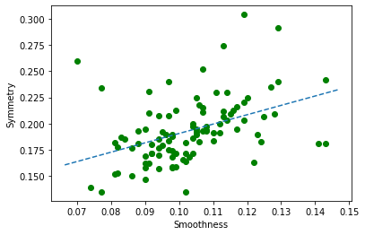

```python
# Scatterplot using matplotlib scatter function

#line from abline()
plt.scatter(df.smoothness, df.symmetry,color='g')
abline(0.1015,0.8919)
plt.xlabel("Smoothness")
plt.ylabel("Symmetry")
plt.show()
```

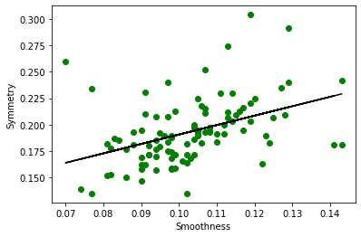

```python
#Using sklearn.linear_model.LinearRegression

from sklearn.linear_model import LinearRegression
X = df['smoothness'].values[:,np.newaxis]
# target data is array of shape (n,)
y = df['symmetry'].values
model2 = LinearRegression()
model2.fit(X, y)

plt.scatter(X, y,color='g')
plt.plot(X, model2.predict(X),color='k')
plt.xlabel("Smoothness")
plt.ylabel("Symmetry")
plt.show()
```

**Give a 95% confidence interval for $\beta_0$ and $\beta_1$. The formula for confidence intervals for $\hat{\beta}_0$ and $\hat{\beta}_1$ involves calculation of standard errors.**

```python
#We can find the standard errors from ols() function

import statsmodels.api as sm
def conf_betas(x, y):
    x = sm.add_constant(x)
    results = sm.OLS(y, x).fit()
    se = results.bse
    b0_ci_l = results.params[0] - se[0]
    b0_ci_h = results.params[0] + se[0]
    b1_ci_l = results.params[1] - se[1]
    b1_ci_h = results.params[1] + se[1]
    print('the confidence intervals for b0 and b1 are')
    return b0_ci_l, b0_ci_h, b1_ci_l, b1_ci_h
```

```python
#Test
x = np.arange(1, 11)
y = 1 + 2*x
conf_betas(x, y)
```

```
the confidence intervals for b0 and b1 are
```

```
(0.9999999999999972, 1.000000000000001, 2.0, 2.000000000000001)
```

**Use the statsmodels `ols()` function to fit a linear model `lmFit`.**

```python
import statsmodels.api as sm
x = df['smoothness'].tolist()
y = df['symmetry'].tolist()
x = sm.add_constant(x)
lmFit = sm.OLS(y, x).fit()
print(lmFit.summary())
```

```
                            OLS Regression Results
==============================================================================
Dep. Variable:                      y   R-squared:                       0.180
Model:                            OLS   Adj. R-squared:                  0.172
Method:                 Least Squares   F-statistic:                     21.50
Date:                Thu, 31 Jul 2025   Prob (F-statistic):           1.09e-05
Time:                        11:27:06   Log-Likelihood:                 216.60
No. Observations:                 100   AIC:                            -429.2
Df Residuals:                      98   BIC:                            -424.0
Df Model:                           1
Covariance Type:            nonrobust
==============================================================================
                 coef    std err          t      P>|t|      [0.025      0.975]
------------------------------------------------------------------------------
const          0.1015      0.020      5.088      0.000       0.062       0.141
x1             0.8919      0.192      4.637      0.000       0.510       1.274
==============================================================================
Omnibus:                       26.568   Durbin-Watson:                   2.037
Prob(Omnibus):                  0.000   Jarque-Bera (JB):               42.850
Skew:                           1.157   Prob(JB):                     4.96e-10
Kurtosis:                       5.220   Cond. No.                         69.4
==============================================================================

Notes:
[1] Standard Errors assume that the covariance matrix of the errors is correctly specified.
```

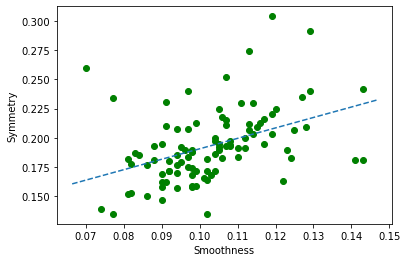

```python
plt.scatter(X, y,color='g')
plt.xlabel("Smoothness")
plt.ylabel("Symmetry")
abline(0.1015,0.8919)
plt.show()
```

The market historical data set of real estate valuation are collected from Sindian Dist., New Taipei City, Taiwan

The inputs are as follows

transaction_date=the transaction date (for example, 2013.250=2013 March, 2013.500=2013 June, etc.)  
house_age = the house age (unit: year)  
distance_station=the distance to the nearest MRT station (unit: meter)  
num_conv_stores=the number of convenience stores in the living circle on foot (integer)  
latitude=the geographic coordinate, latitude. (unit: degree) longitude=the geographic coordinate, longitude. (unit: degree)

The output is as follows

price_per_unit_area= house price of unit area (10000 New Taiwan Dollar/Ping, where Ping is a local unit, 1 Ping = 3.3 meter squared)

Our goal is to fit a multiple linear regression model to predict the price per unit of area of the houses. Note that there are some variables in the data set that are not meaningful without further processing for modeling the house price. You should exclude them.

```python
df2 = pd.read_excel('RealEstateValuation.xlsx')
df2
```

|  | transaction_date | house_age | distance_station | num_conv_stores | latitude | longitude | price_per_unit_area |
| --- | --- | --- | --- | --- | --- | --- | --- |
| 0 | 2012.916667 | 32.0 | 84.87882 | 10 | 24.98298 | 121.54024 | 37.9 |
| 1 | 2012.916667 | 19.5 | 306.59470 | 9 | 24.98034 | 121.53951 | 42.2 |
| 2 | 2013.583333 | 13.3 | 561.98450 | 5 | 24.98746 | 121.54391 | 47.3 |
| 3 | 2013.500000 | 13.3 | 561.98450 | 5 | 24.98746 | 121.54391 | 54.8 |
| 4 | 2012.833333 | 5.0 | 390.56840 | 5 | 24.97937 | 121.54245 | 43.1 |
| ... | ... | ... | ... | ... | ... | ... | ... |
| 409 | 2013.000000 | 13.7 | 4082.01500 | 0 | 24.94155 | 121.50381 | 15.4 |
| 410 | 2012.666667 | 5.6 | 90.45606 | 9 | 24.97433 | 121.54310 | 50.0 |
| 411 | 2013.250000 | 18.8 | 390.96960 | 7 | 24.97923 | 121.53986 | 40.6 |
| 412 | 2013.000000 | 8.1 | 104.81010 | 5 | 24.96674 | 121.54067 | 52.5 |
| 413 | 2013.500000 | 6.5 | 90.45606 | 9 | 24.97433 | 121.54310 | 63.9 |

414 rows × 7 columns

**Create a subset of the data set by using only the relevant variables for modeling purposes.**

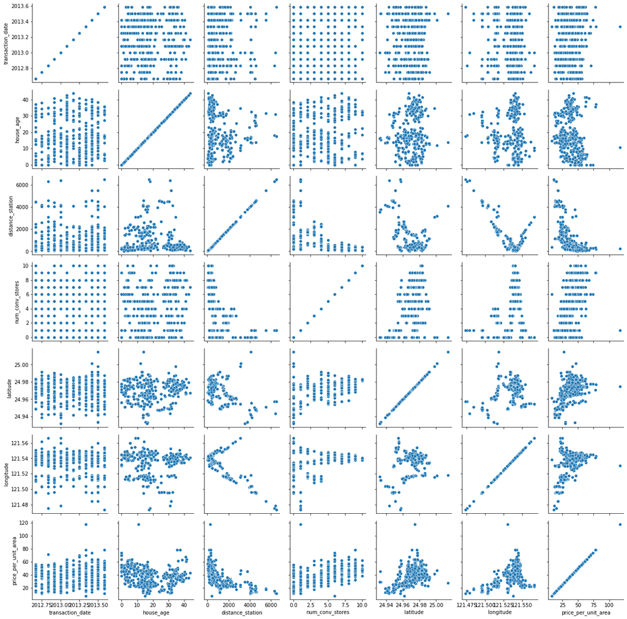

```python
df2_subset = df2[['transaction_date', 'house_age', 'distance_station', 'num_conv_stores', 'latitude', 'longitude']]

g = sns.PairGrid(df2)
g.map(sns.scatterplot)
```

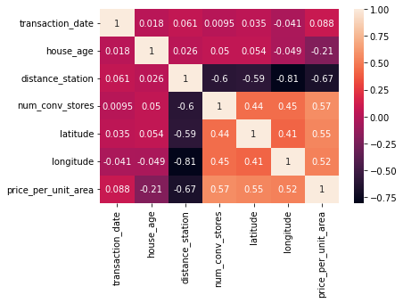

```python
# Produce the correlation matrix
import seaborn as sn
import matplotlib.pyplot as plt
corr_matrix = df2.corr()
sn.heatmap(corr_matrix, annot=True)
plt.show()
```

House price is highly negatively correlated with distance_station, and moderately positively correlated with num_conv_stores, latitude and longitude.

**Plot the true price_per_unit_area against the estimated price_per_unit_area. Plot the diagonal line.**

```python
x = df2_subset
y = df2[['price_per_unit_area']]
x = sm.add_constant(x)
model = sm.OLS(y, x)
```

```python
results = model.fit()
predicted_results = pd.DataFrame(results.fittedvalues)
```

```python
print(results.summary())
```

```
                             OLS Regression Results
===============================================================================
Dep. Variable:     price_per_unit_area   R-squared:                       0.582
Model:                             OLS   Adj. R-squared:                  0.576
Method:                  Least Squares   F-statistic:                     94.60
Date:                 Thu, 31 Jul 2025   Prob (F-statistic):           4.83e-74
Time:                         11:38:43   Log-Likelihood:                -1487.0
No. Observations:                  414   AIC:                             2988.
Df Residuals:                      407   BIC:                             3016.
Df Model:                            6
Covariance Type:             nonrobust
====================================================================================
                       coef    std err          t      P>|t|      [0.025      0.975]
------------------------------------------------------------------------------------
const            -1.444e+04   6775.386     -2.132      0.034   -2.78e+04   -1122.863
transaction_date     5.1490      1.557      3.307      0.001       2.088       8.210
house_age           -0.2697      0.039     -7.000      0.000      -0.345      -0.194
distance_station    -0.0045      0.001     -6.250      0.000      -0.006      -0.003
num_conv_stores      1.1333      0.188      6.023      0.000       0.763       1.503
latitude           225.4701     44.566      5.059      0.000     137.862     313.078
longitude          -12.4291     48.581     -0.256      0.798    -107.930      83.072
==============================================================================
Omnibus:                      231.615   Durbin-Watson:                   2.153
Prob(Omnibus):                  0.000   Jarque-Bera (JB):             3598.692
Skew:                           2.026   Prob(JB):                         0.00
Kurtosis:                      16.864   Cond. No.                     3.72e+07
==============================================================================

Notes:
[1] Standard Errors assume that the covariance matrix of the errors is correctly specified.
[2] The condition number is large, 3.72e+07. This might indicate that there are
strong multicollinearity or other numerical problems.
```

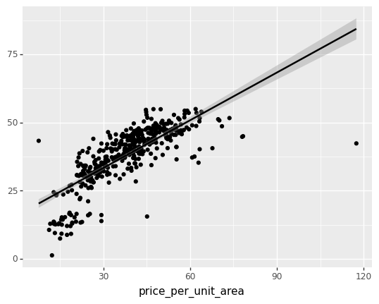

```python
plot = ggplot(aes(x= df2.price_per_unit_area, y= predicted_results))
plot + geom_point()+ geom_smooth(method="lm",size=1)
```

The model is overestimating at the points above the line, and underestimating at the points below the line. The points have a curvy shape so we can also use a polynomial model (log-concave).

# KNeighborsClassifier

**Load and normalize the data**

```python
df = pd.read_csv('prostate_cancer.csv')
df.head()
```

|  | id | diagnosis_result | radius | texture | perimeter | area | smoothness | compactness | symmetry | fractal_dimension |
| --- | --- | --- | --- | --- | --- | --- | --- | --- | --- | --- |
| 0 | 1 | M | 23 | 12 | 151 | 954 | 0.143 | 0.278 | 0.242 | 0.079 |
| 1 | 2 | B | 9 | 13 | 133 | 1326 | 0.143 | 0.079 | 0.181 | 0.057 |
| 2 | 3 | M | 21 | 27 | 130 | 1203 | 0.125 | 0.160 | 0.207 | 0.060 |
| 3 | 4 | M | 14 | 16 | 78 | 386 | 0.070 | 0.284 | 0.260 | 0.097 |
| 4 | 5 | M | 9 | 19 | 135 | 1297 | 0.141 | 0.133 | 0.181 | 0.059 |

```python
df['radius'] = ( df['radius'] - min(df['radius'])/max(df['radius'])-min(df['radius']))
df['texture'] = ( df['texture'] - min(df['texture'])/max(df['texture'])-min(df['texture']))
df['perimeter'] = ( df['perimeter'] - min(df['perimeter'])/max(df['perimeter'])-min(df['perimeter']))
df['area'] = ( df['area'] - min(df['area'])/max(df['area'])-min(df['area']))
df['smoothness'] = ( df['smoothness'] - min(df['smoothness'])/max(df['smoothness'])-min(df['smoothness']))
df['compactness'] = ( df['compactness'] - min(df['compactness'])/max(df['compactness'])-min(df['compactness']))
df['symmetry'] = ( df['symmetry'] - min(df['symmetry'])/max(df['symmetry'])-min(df['symmetry']))
df['fractal_dimension'] = ( df['fractal_dimension'] - min(df['fractal_dimension'])/max(df['fractal_dimension'])-min(df['fractal_dimension']))
```

```python
df.head()
```

|  | id | diagnosis_result | radius | texture | perimeter | area | smoothness | compactness | symmetry | fractal_dimension |
| --- | --- | --- | --- | --- | --- | --- | --- | --- | --- | --- |
| 0 | 1 | M | 13.64 | 0.592593 | 98.697674 | 751.892439 | -0.41651 | 0.129855 | -0.337079 | -0.520392 |
| 1 | 2 | B | -0.36 | 1.592593 | 80.697674 | 1123.892439 | -0.41651 | -0.069145 | -0.398079 | -0.542392 |
| 2 | 3 | M | 11.64 | 15.592593 | 77.697674 | 1000.892439 | -0.43451 | 0.011855 | -0.372079 | -0.539392 |
| 3 | 4 | M | 4.64 | 4.592593 | 25.697674 | 183.892439 | -0.48951 | 0.135855 | -0.319079 | -0.502392 |
| 4 | 5 | M | -0.36 | 7.592593 | 82.697674 | 1094.892439 | -0.41851 | -0.015145 | -0.398079 | -0.540392 |

**Divide the data into training and testing sets. Use `train_test_split` from `sklearn` and set a random state of 19. Keep 65% examples in your training set and the rest in your test set.**

```python
X = df.drop(columns=['diagnosis_result'])
y = df['diagnosis_result'].values
y[0:5]
```

```
array(['M', 'B', 'M', 'M', 'M'], dtype=object)
```

```python
from sklearn.model_selection import train_test_split
X_train, X_test, y_train, y_test = train_test_split(X, y, test_size=0.35, random_state=19)
```

**Use KNeighborsClassifier from sklearn with k = 10 to classify the data.**

```python
from sklearn.neighbors import KNeighborsClassifier
knn = KNeighborsClassifier(n_neighbors = 10)
knn.fit(X_train,y_train)
knn.predict(X_test)
#check accuracy of our model on the test data
knn.score(X_test, y_test)
```

```
0.8285714285714286
```

**On running this for k = 1,2,3,4,5,6,7,8,9,10,20,30,40,50 how many are misclassified on the testing set for each value?**

```python
def classification(k):
    knn = KNeighborsClassifier(n_neighbors = k)
    knn.fit(X_train,y_train)
    knn.predict(X_test)
    score = knn.score(X_test, y_test)
    misclassified = (1-score) * 35
    return misclassified
```